# Matrix Algebra Homework

SALMA AGA SHAIK

2023-03-01

NOTE: Please do not use any of these functions - stats::prcomp(), FactoMiner::PCA(), ade4::dudi.pca(), ExPosition::epPCA() for completing this homework. You can use these functions to cross check your answers.

Load tidyverse,matlib,corpcor,dbplyr,matrixcalc,ibd and ggplot2 libraries.

```r
library(tidyverse)
library(matlib)
library(corpcor)
library(dbplyr)
library(matrixcalc)
```

```r
library(ibd)
library(ggplot2)
```

Lets load the ggplot2::midwest dataset and assign it into indata variable

```r
indata <- ggplot2::midwest
indata
```

```
## # A tibble: 437 × 28
##      PID county    state  area poptotal popden…¹ popwh…² popbl…³ popam…⁴ popas…⁵
##    <int> <chr>     <chr> <dbl>    <int>    <dbl>   <int>   <int>   <int>   <int>
##  1   561 ADAMS     IL    0.052    66090    1271.   63917    1702      98     249
##  2   562 ALEXANDER IL    0.014    10626     759     7054    3496      19      48
##  3   563 BOND      IL    0.022    14991     681.   14477     429      35      16
##  4   564 BOONE     IL    0.017    30806    1812.   29344     127      46     150
##  5   565 BROWN     IL    0.018     5836     324.    5264     547      14       5
##  6   566 BUREAU    IL    0.05     35688     714.   35157      50      65     195
##  7   567 CALHOUN   IL    0.017     5322     313.    5298       1       8      15
##  8   568 CARROLL   IL    0.027    16805     622.   16519     111      30      61
##  9   569 CASS      IL    0.024    13437     560.   13384      16       8      23
## 10   570 CHAMPAIGN IL    0.058   173025    2983.  146506   16559     331    8033
## # … with 427 more rows, 18 more variables: popother <int>, percwhite <dbl>,
## #   percblack <dbl>, percamerindan <dbl>, percasian <dbl>, percother <dbl>,
## #   popadults <int>, perchsd <dbl>, percollege <dbl>, percprof <dbl>,
## #   poppovertyknown <int>, percpovertyknown <dbl>, percbelowpoverty <dbl>,
## #   percchildbelowpovert <dbl>, percadultpoverty <dbl>,
## #   percelderlypoverty <dbl>, inmetro <int>, category <chr>, and abbreviated
## #   variable names ¹popdensity, ²popwhite, ³popblack, ⁴popamerindian, …
```

Output : From the above result we can see that there are 437 rows and 28 columns.

## Question 1

Consider the inbuilt dataset `ggplot2::midwest`. Please use `help()` to learn more about the data.

### Task 1: Generate the covariance matrix. What can you say about the variables in the data

##Eliminating columns containing categorical variables and considering the first 25 observations for analysis to facilitate observation

```r
indata1 <- indata[c(1:25),c(1,4,5,6,7,8,9,10,11,12,13,14,15,16,17,18,19,20,21,22,23,24,25,26,27)]
```

Output : After elimination, 25 observations and 25 variables remained.

## Transforming a data set into matrix form and calculating covariance of the matrix

```r
indata2 <-as.matrix(indata1)
indata_covariance = cov(indata2)
indata_covariance
```

```
##                                PID          area      poptotal    popdensity
## PID                   5.416667e+01 -7.500000e-03  9.003590e+05  2.507724e+04
## area                 -7.500000e-03  1.707233e-04  5.947759e+03  9.034270e+01
## poptotal              9.003590e+05  5.947759e+03  1.040634e+12  1.840197e+10
## popdensity            2.507724e+04  9.034270e+01  1.840197e+10  3.507201e+08
## popwhite              6.433413e+05  3.714091e+03  6.562270e+11  1.181970e+10
## popblack              1.661600e+05  1.558058e+03  2.658243e+11  4.520742e+09
## popamerindian         1.578042e+03  1.218682e+01  2.086663e+09  3.629656e+07
## popasian              3.770842e+04  2.152629e+02  3.882586e+10  6.978335e+08
## popother              5.157129e+04  4.481603e+02  7.766984e+10  1.327403e+09
## percwhite             1.508905e+01 -3.266620e-02 -6.847037e+06 -1.208020e+05
## percblack            -1.701911e+01  1.640632e-02  4.616595e+06  7.736859e+04
## percamerindan        -1.286829e-01  1.239442e-04  9.193271e+03  1.242424e+02
## percasian             1.952222e+00  8.096758e-03  7.580841e+05  1.739674e+04
## percother             1.065247e-01  8.039178e-03  1.463164e+06  2.591241e+04
## popadults             5.789036e+05  3.816288e+03  6.711435e+11  1.186738e+10
## perchsd               1.572249e+01  3.789144e-02  5.950584e+05  2.607472e+04
## percollege            1.711159e+01  4.829230e-02  2.736143e+06  7.146462e+04
## percprof              3.440144e+00  2.314837e-02  1.038656e+06  2.517312e+04
## poppovertyknown       8.877099e+05  5.830405e+03  1.024268e+12  1.811635e+10
## percpovertyknown      5.860273e+00 -7.713220e-03  4.651242e+05  1.054118e+04
## percbelowpoverty     -1.334406e+01 -9.801007e-04 -4.176988e+04 -1.156115e+04
## percchildbelowpovert -1.856001e+01 -9.567833e-04  8.888908e+05  1.425289e+03
## percadultpoverty     -9.879173e+00  5.311783e-03 -2.014561e+05 -1.304742e+04
## percelderlypoverty   -1.431765e+01 -2.028657e-02 -5.968885e+05 -1.928214e+04
## inmetro               2.916667e-01  1.706667e-03  1.923097e+05  4.140552e+03
##                           popwhite      popblack popamerindian      popasian
## PID                   6.433413e+05  1.661600e+05  1.578042e+03  3.770842e+04
## area                  3.714091e+03  1.558058e+03  1.218682e+01  2.152629e+02
## poptotal              6.562270e+11  2.658243e+11  2.086663e+09  3.882586e+10
## popdensity            1.181970e+10  4.520742e+09  3.629656e+07  6.978335e+08
## popwhite              4.157294e+11  1.660403e+11  1.310660e+09  2.458069e+10
## popblack              1.660403e+11  6.922635e+10  5.373628e+08  9.836766e+09
## popamerindian         1.310660e+09  5.373628e+08  4.198632e+06  7.758540e+07
## popasian              2.458069e+10  9.836766e+09  7.758540e+07  1.454100e+09
## popother              4.856596e+10  2.018351e+10  1.568562e+08  2.876715e+09
## percwhite            -4.318607e+06 -1.749497e+06 -1.374978e+04 -2.567523e+05
## percblack             2.870921e+06  1.213607e+06  9.374513e+03  1.714723e+05
## percamerindan         5.522911e+03  2.583628e+03  1.958739e+01  3.287135e+02
## percasian             5.188627e+05  1.600755e+05  1.421139e+03  3.042835e+04
```

[output cut: 127 more lines]

```
## percblack                2.411566e+01       1.585275e+01  8.567169e-01
## percamerindan            3.541597e-02       2.037809e-02  1.515252e-03
## percasian               -9.126703e-02      -3.098205e+00  4.671439e-01
## percother               -9.928155e-01      -2.354880e+00  4.451060e-01
## popadults               -1.363700e+05      -3.792720e+05  1.231655e+05
## perchsd                 -1.054213e+01      -2.533785e+01  1.454413e+00
## percollege              -2.013268e+00      -2.461113e+01  2.526066e+00
## percprof                 3.138255e+00      -8.378278e+00  1.104882e+00
## poppovertyknown         -2.061610e+05      -5.836946e+05  1.886352e+05
## percpovertyknown        -6.521069e+00       3.737772e-01 -3.711447e-01
## percbelowpoverty         2.386214e+01       1.796614e+01 -5.812669e-01
## percchildbelowpovert     2.770911e+01       2.386336e+01 -9.682049e-01
## percadultpoverty         2.466064e+01       1.309423e+01 -2.240996e-01
## percelderlypoverty       1.309423e+01       2.248716e+01 -1.202140e+00
## inmetro                 -2.240996e-01      -1.202140e+00  1.900000e-01
```

Output : The covariance of vectors is computed to determine how one variable differs from another, or to determine the relationship between two values. I observed both positive and negative covariances in the data presented here.

## Need to check for dimensions

```r
dim(indata_covariance)
```

```
## [1] 25 25
```

Output : I can see that from the above result there are 25 rows and 25 columns

## By using head() function check 1st 6 rows

```r
head(indata_covariance)
```

```
##                     PID          area     poptotal   popdensity     popwhite
## PID            54.16667 -7.500000e-03 9.003590e+05 2.507724e+04 6.433413e+05
## area           -0.00750  1.707233e-04 5.947759e+03 9.034270e+01 3.714091e+03
## poptotal   900359.00000  5.947759e+03 1.040634e+12 1.840197e+10 6.562270e+11
## popdensity  25077.23791  9.034270e+01 1.840197e+10 3.507201e+08 1.181970e+10
## popwhite   643341.29167  3.714091e+03 6.562270e+11 1.181970e+10 4.157294e+11
## popblack   166159.95833  1.558058e+03 2.658243e+11 4.520742e+09 1.660403e+11
##                popblack popamerindian     popasian     popother     percwhite
## PID        1.661600e+05  1.578042e+03 3.770842e+04 5.157129e+04  1.508905e+01
## area       1.558058e+03  1.218682e+01 2.152629e+02 4.481603e+02 -3.266620e-02
## poptotal   2.658243e+11  2.086663e+09 3.882586e+10 7.766984e+10 -6.847037e+06
## popdensity 4.520742e+09  3.629656e+07 6.978335e+08 1.327403e+09 -1.208020e+05
## popwhite   1.660403e+11  1.310660e+09 2.458069e+10 4.856596e+10 -4.318607e+06
## popblack   6.922635e+10  5.373628e+08 9.836766e+09 2.018351e+10 -1.749497e+06
##                percblack percamerindan    percasian    percother    popadults
## PID        -1.701911e+01 -1.286829e-01 1.952222e+00 1.065247e-01 5.789036e+05
## area        1.640632e-02  1.239442e-04 8.096758e-03 8.039178e-03 3.816288e+03
## poptotal    4.616595e+06  9.193271e+03 7.580841e+05 1.463164e+06 6.711435e+11
## popdensity  7.736859e+04  1.242424e+02 1.739674e+04 2.591241e+04 1.186738e+10
## popwhite    2.870921e+06  5.522911e+03 5.188627e+05 9.232996e+05 4.231939e+11
## popblack    1.213607e+06  2.583628e+03 1.600755e+05 3.732310e+05 1.714642e+11
##                 perchsd   percollege     percprof poppovertyknown
## PID        1.572249e+01 1.711159e+01 3.440144e+00    8.877099e+05
## area       3.789144e-02 4.829230e-02 2.314837e-02    5.830405e+03
## poptotal   5.950584e+05 2.736143e+06 1.038656e+06    1.024268e+12
## popdensity 2.607472e+04 7.146462e+04 2.517312e+04    1.811635e+10
## popwhite   5.463443e+05 1.971245e+06 7.374377e+05    6.459134e+11
## popblack   1.200015e+04 4.976604e+05 1.984504e+05    2.616358e+11
##            percpovertyknown percbelowpoverty percchildbelowpovert
## PID            5.860273e+00    -1.334406e+01        -1.856001e+01
## area          -7.713220e-03    -9.801007e-04        -9.567833e-04
## poptotal       4.651242e+05    -4.176988e+04         8.888908e+05
## popdensity     1.054118e+04    -1.156115e+04         1.425289e+03
## popwhite       2.981350e+05    -1.216336e+05         4.232049e+05
## popblack       1.134303e+05     6.928613e+04         3.415507e+05
##            percadultpoverty percelderlypoverty      inmetro
## PID           -9.879173e+00      -1.431765e+01 2.916667e-01
## area           5.311783e-03      -2.028657e-02 1.706667e-03
## poptotal      -2.014561e+05      -5.968885e+05 1.923097e+05
## popdensity    -1.304742e+04      -1.928214e+04 4.140552e+03
## popwhite      -2.013560e+05      -4.686735e+05 1.290465e+05
## popblack       1.175211e+04      -7.680240e+04 4.274985e+04
```

```r
tail(indata_covariance)
```

```
##                              PID          area   poptotal popdensity  popwhite
## percpovertyknown       5.8602735 -0.0077132200  465124.24  10541.184  298135.0
## percbelowpoverty     -13.3440630 -0.0009801007  -41769.88 -11561.150 -121633.6
## percchildbelowpovert -18.5600075 -0.0009567833  888890.85   1425.289  423204.9
## percadultpoverty      -9.8791728  0.0053117826 -201456.12 -13047.419 -201356.0
## percelderlypoverty   -14.3176527 -0.0202865665 -596888.54 -19282.141 -468673.5
## inmetro                0.2916667  0.0017066667  192309.69   4140.552  129046.5
##                       popblack popamerindian   popasian    popother  percwhite
## percpovertyknown     113430.32      879.5865  18017.065  34662.2332   3.794236
## percbelowpoverty      69286.13      178.8152  -5702.428  16101.1999 -25.929073
## percchildbelowpovert 341550.66     2134.0658  27128.808  94872.4414 -41.223913
## percadultpoverty      11752.11     -178.5985 -11020.697   -652.9287 -23.066989
## percelderlypoverty   -76802.40     -975.4906 -25483.111 -24953.9962 -10.420046
## inmetro               42749.85      367.2750   7530.142  12615.9750  -1.770482
##                       percblack percamerindan   percasian    percother
## percpovertyknown     -3.2100457  -0.090399792 -1.02996786  0.536177390
## percbelowpoverty     28.1516927   0.032279817 -1.21427722 -1.040622010
## percchildbelowpovert 43.6693840   0.027436149 -2.47568668  0.002779653
## percadultpoverty     24.1156554   0.035415969 -0.09126703 -0.992815466
## percelderlypoverty   15.8527526   0.020378092 -3.09820464 -2.354880020
## inmetro               0.8567169   0.001515252  0.46714392  0.445106044
##                       popadults    perchsd percollege  percprof poppovertyknown
## percpovertyknown      308220.32  -6.289265 -11.249537 -6.979540       466914.73
## percbelowpoverty      -28685.68 -18.171218 -11.877097 -1.462938       -44705.78
## percchildbelowpovert  578118.07 -29.295295 -25.020433 -7.512210       876964.76
## percadultpoverty     -136369.98 -10.542128  -2.013268  3.138255      -206161.03
## percelderlypoverty   -379271.97 -25.337850 -24.611131 -8.378278      -583694.64
## inmetro               123165.54   1.454413   2.526066  1.104882       188635.18
##                      percpovertyknown percbelowpoverty percchildbelowpovert
## percpovertyknown           18.4023563       -2.3523952            6.3554329
## percbelowpoverty           -2.3523952       25.9435494           34.3363272
## percchildbelowpovert        6.3554329       34.3363272           55.4132923
## percadultpoverty           -6.5210691       23.8621363           27.7091134
## percelderlypoverty          0.3737772       17.9661442           23.8633587
## inmetro                    -0.3711447       -0.5812669           -0.9682049
##                      percadultpoverty percelderlypoverty    inmetro
## percpovertyknown           -6.5210691          0.3737772 -0.3711447
## percbelowpoverty           23.8621363         17.9661442 -0.5812669
## percchildbelowpovert       27.7091134         23.8633587 -0.9682049
## percadultpoverty           24.6606406         13.0942259 -0.2240996
## percelderlypoverty         13.0942259         22.4871561 -1.2021402
## inmetro                    -0.2240996         -1.2021402  0.1900000
```

### Task 2: Check if the covariance matrix is orthogonal

# For checking orthogonal matrix or not we need to use a function called check.orthogonality()

```r
check.orthogonality(indata_covariance)
```

```
## [1] 0
```

Output : Above matrix is not an orthogonal matrix.

# Need to check covariance matrix is orthogonal or not by using a function called is_orthogonal_matrix

```r
is_orthogonal_matrix(indata_covariance)
```

```
## [1] FALSE
```

Output : From the above result we can see that the covariance matrix is not an orthogonal.

### Task 3: Compute the eigenvalues and eigenvectors for covariance matrix. What did you observe from your analysis?

# For checking eigen values we need to use a function called eigen()

```r
indata_Eigen = eigen(indata_covariance)
indata_covariance
```

```
##                                PID          area      poptotal    popdensity
## PID                   5.416667e+01 -7.500000e-03  9.003590e+05  2.507724e+04
## area                 -7.500000e-03  1.707233e-04  5.947759e+03  9.034270e+01
## poptotal              9.003590e+05  5.947759e+03  1.040634e+12  1.840197e+10
## popdensity            2.507724e+04  9.034270e+01  1.840197e+10  3.507201e+08
## popwhite              6.433413e+05  3.714091e+03  6.562270e+11  1.181970e+10
## popblack              1.661600e+05  1.558058e+03  2.658243e+11  4.520742e+09
## popamerindian         1.578042e+03  1.218682e+01  2.086663e+09  3.629656e+07
## popasian              3.770842e+04  2.152629e+02  3.882586e+10  6.978335e+08
## popother              5.157129e+04  4.481603e+02  7.766984e+10  1.327403e+09
## percwhite             1.508905e+01 -3.266620e-02 -6.847037e+06 -1.208020e+05
## percblack            -1.701911e+01  1.640632e-02  4.616595e+06  7.736859e+04
## percamerindan        -1.286829e-01  1.239442e-04  9.193271e+03  1.242424e+02
## percasian             1.952222e+00  8.096758e-03  7.580841e+05  1.739674e+04
## percother             1.065247e-01  8.039178e-03  1.463164e+06  2.591241e+04
## popadults             5.789036e+05  3.816288e+03  6.711435e+11  1.186738e+10
## perchsd               1.572249e+01  3.789144e-02  5.950584e+05  2.607472e+04
## percollege            1.711159e+01  4.829230e-02  2.736143e+06  7.146462e+04
## percprof              3.440144e+00  2.314837e-02  1.038656e+06  2.517312e+04
## poppovertyknown       8.877099e+05  5.830405e+03  1.024268e+12  1.811635e+10
## percpovertyknown      5.860273e+00 -7.713220e-03  4.651242e+05  1.054118e+04
## percbelowpoverty     -1.334406e+01 -9.801007e-04 -4.176988e+04 -1.156115e+04
## percchildbelowpovert -1.856001e+01 -9.567833e-04  8.888908e+05  1.425289e+03
## percadultpoverty     -9.879173e+00  5.311783e-03 -2.014561e+05 -1.304742e+04
## percelderlypoverty   -1.431765e+01 -2.028657e-02 -5.968885e+05 -1.928214e+04
## inmetro               2.916667e-01  1.706667e-03  1.923097e+05  4.140552e+03
##                           popwhite      popblack popamerindian      popasian
## PID                   6.433413e+05  1.661600e+05  1.578042e+03  3.770842e+04
## area                  3.714091e+03  1.558058e+03  1.218682e+01  2.152629e+02
## poptotal              6.562270e+11  2.658243e+11  2.086663e+09  3.882586e+10
## popdensity            1.181970e+10  4.520742e+09  3.629656e+07  6.978335e+08
## popwhite              4.157294e+11  1.660403e+11  1.310660e+09  2.458069e+10
## popblack              1.660403e+11  6.922635e+10  5.373628e+08  9.836766e+09
## popamerindian         1.310660e+09  5.373628e+08  4.198632e+06  7.758540e+07
## popasian              2.458069e+10  9.836766e+09  7.758540e+07  1.454100e+09
## popother              4.856596e+10  2.018351e+10  1.568562e+08  2.876715e+09
## percwhite            -4.318607e+06 -1.749497e+06 -1.374978e+04 -2.567523e+05
## percblack             2.870921e+06  1.213607e+06  9.374513e+03  1.714723e+05
## percamerindan         5.522911e+03  2.583628e+03  1.958739e+01  3.287135e+02
## percasian             5.188627e+05  1.600755e+05  1.421139e+03  3.042835e+04
```

[output cut: 127 more lines]

```
## percblack                2.411566e+01       1.585275e+01  8.567169e-01
## percamerindan            3.541597e-02       2.037809e-02  1.515252e-03
## percasian               -9.126703e-02      -3.098205e+00  4.671439e-01
## percother               -9.928155e-01      -2.354880e+00  4.451060e-01
## popadults               -1.363700e+05      -3.792720e+05  1.231655e+05
## perchsd                 -1.054213e+01      -2.533785e+01  1.454413e+00
## percollege              -2.013268e+00      -2.461113e+01  2.526066e+00
## percprof                 3.138255e+00      -8.378278e+00  1.104882e+00
## poppovertyknown         -2.061610e+05      -5.836946e+05  1.886352e+05
## percpovertyknown        -6.521069e+00       3.737772e-01 -3.711447e-01
## percbelowpoverty         2.386214e+01       1.796614e+01 -5.812669e-01
## percchildbelowpovert     2.770911e+01       2.386336e+01 -9.682049e-01
## percadultpoverty         2.466064e+01       1.309423e+01 -2.240996e-01
## percelderlypoverty       1.309423e+01       2.248716e+01 -1.202140e+00
## inmetro                 -2.240996e-01      -1.202140e+00  1.900000e-01
```

## storing values and vectors in separate variables and evaluating for non-negative values

```r
indata_Eigenvalues <- eigen(indata_covariance)$values
indata_Eigenvectors <- eigen(indata_covariance)$vectors
is.nan(indata_Eigenvalues)
```

```
##  [1] FALSE FALSE FALSE FALSE FALSE FALSE FALSE FALSE FALSE FALSE FALSE FALSE
## [13] FALSE FALSE FALSE FALSE FALSE FALSE FALSE FALSE FALSE FALSE FALSE FALSE
## [25] FALSE
```

```r
indata_Eigenvalues
```

```
##  [1]  2.971053e+12  3.245477e+09  1.476048e+07  9.224207e+05  3.674958e+05
##  [6]  8.596415e+04  6.300975e+04  8.163012e+01  6.610113e+01  2.227426e+01
## [11]  1.282003e+01  9.860828e+00  3.479023e+00  1.447247e+00  9.646363e-01
## [16]  3.307089e-01  1.145729e-01  1.785055e-02  9.152650e-03  8.859934e-04
## [21]  4.356346e-04  4.329762e-04  4.088493e-05 -1.214593e-13 -2.039272e-04
```

Output:As seen, the matrix’s 24th and 25th columns have negative Eigen values.

## Need to convert negative values into positive values.

```r
indata_Eigenvalues[24]= -1*indata_Eigenvalues[24]
indata_Eigenvalues[25]= -1*indata_Eigenvalues[25]
indata_Eigenvalues
```

```
##  [1] 2.971053e+12 3.245477e+09 1.476048e+07 9.224207e+05 3.674958e+05
##  [6] 8.596415e+04 6.300975e+04 8.163012e+01 6.610113e+01 2.227426e+01
## [11] 1.282003e+01 9.860828e+00 3.479023e+00 1.447247e+00 9.646363e-01
## [16] 3.307089e-01 1.145729e-01 1.785055e-02 9.152650e-03 8.859934e-04
## [21] 4.356346e-04 4.329762e-04 4.088493e-05 1.214593e-13 2.039272e-04
```

Output: There are no negative values.

### Task 4: Find the squareroot of the covariance matrix using the spectral decomposition method

```r
indata_Squareroot <- indata_Eigenvalues %*% diag(sqrt(indata_Eigenvalues)) %*% t(indata_Eigenvectors)
indata_Squareroot
```

```
##             [,1]        [,2]         [,3]         [,4]         [,5]
## [1,] 2.65934e+12 17268788663 3.030734e+18 5.370222e+16 1.912111e+18
##              [,6]         [,7]         [,8]         [,9]        [,10]
## [1,] 7.734163e+17 6.074589e+15 1.131231e+17 2.260095e+17 -1.99297e+13
##             [,11]       [,12]        [,13]        [,14]        [,15]
## [1,] 1.341908e+13 26585825795 2.223185e+12 4.260849e+12 1.954639e+18
##             [,16]        [,17]        [,18]        [,19]        [,20]
## [1,] 1.796658e+12 8.057453e+12 3.047565e+12 2.983093e+18 1.371312e+12
##              [,21]        [,22]         [,23]       [,24]        [,25]
## [1,] -172869145714 2.526956e+12 -634950628424 -1.7761e+12 562678267029
```

### Task 5: Based on the eigen decomposition in task 3, determine how many principal components you would select to reduce number of original features yet capture atleast 85% of the variability in the data?

```r
Variance_Percentage <- eigen(indata_covariance)$values/sum(eigen(indata_covariance)$values)
Variance_Percentage
```

```
##  [1]  9.989034e-01  1.091168e-03  4.962649e-06  3.101288e-07  1.235565e-07
##  [6]  2.890217e-08  2.118463e-08  2.744502e-11  2.222399e-11  7.488870e-12
## [11]  4.310247e-12  3.315328e-12  1.169689e-12  4.865816e-13  3.243222e-13
## [16]  1.111883e-13  3.852079e-14  6.001569e-15  3.077230e-15  2.978816e-16
## [21]  1.464656e-16  1.455717e-16  1.374600e-17 -4.083606e-26 -6.856274e-17
```

Output: To determine which key components offer the highest level of adaptability, we can examine the range of values from the previous step.

# plot of variance percentage

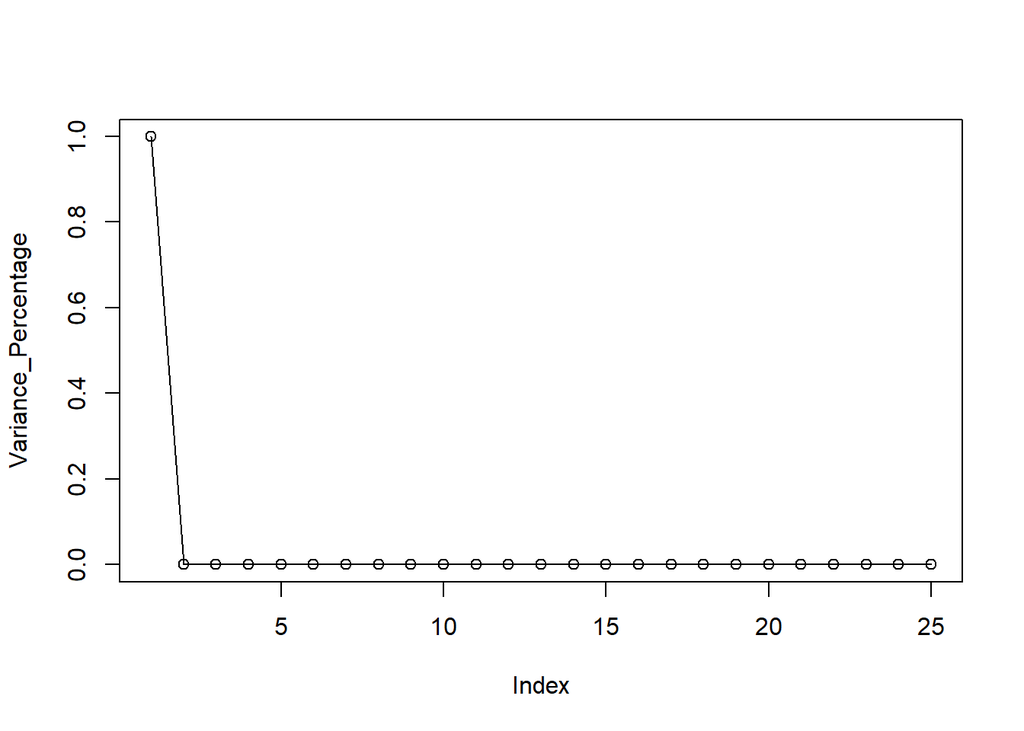

```r
plot(Variance_Percentage,type="o")
```

Output: We can see from the preceding graph that the second value plot becomes stable after the second value has stabilized. Therefore, key values can be assumed to be 1 and 2. From Variance_Percentage, range can also be observed.

# Need to check for cumulative variance percentage

```r
Cumulative_Variance_Percentage = cumsum(Variance_Percentage)
```

Plot cumulative percentage variance

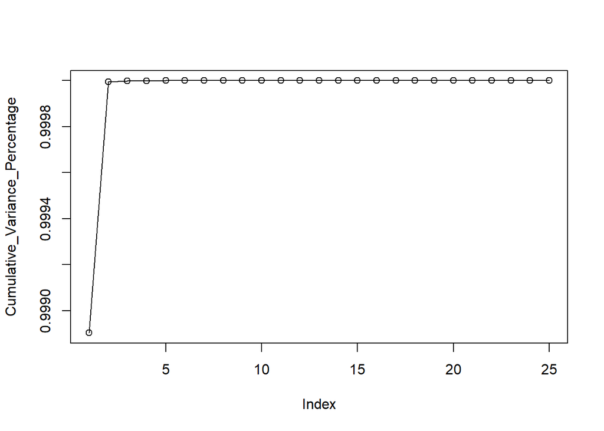

```r
plot(Cumulative_Variance_Percentage,type="o")
```

Output: From the above graph, we can observe that after the second value, the plot is stable.

### Task 6: Compute the principal component vectors based on your selection in task 5. Comment on your interpretation of the PCs

##Therefore, we considered the first and second columns to be the primary components in this illustration.

```r
Eigenvectors = eigen(indata_covariance)$vectors[,1:2]
colnames(Eigenvectors) = c("E1","E2")
row.names(Eigenvectors) = colnames(indata_covariance)
round(Eigenvectors,digits = 5)
```

```
##                           E1       E2
## PID                  0.00000  0.00003
## area                 0.00000  0.00000
## poptotal             0.59181 -0.10711
## popdensity           0.01048  0.08458
## popwhite             0.37335  0.69965
## popblack             0.15105 -0.66564
## popamerindian        0.00119 -0.00230
## popasian             0.02209  0.03505
## popother             0.04414 -0.17386
## percwhite            0.00000  0.00000
## percblack            0.00000 -0.00002
## percamerindan        0.00000  0.00000
## percasian            0.00000  0.00002
## percother            0.00000  0.00000
## popadults            0.38168 -0.08203
## perchsd              0.00000  0.00007
## percollege           0.00000  0.00010
## percprof             0.00000  0.00003
## poppovertyknown      0.58251 -0.10293
## percpovertyknown     0.00000  0.00000
## percbelowpoverty     0.00000 -0.00004
## percchildbelowpovert 0.00000 -0.00006
## percadultpoverty     0.00000 -0.00003
## percelderlypoverty   0.00000 -0.00004
## inmetro              0.00000  0.00000
```

Output: From the output, we can observe the data of key components for all variables, with the digits rounded to 5 to make the value more clear.

# Need to check for principal componets

```r
Scaled_Version = scale(indata_covariance)
E1<-as.matrix(Scaled_Version) %*% Eigenvectors [,1]
E2<-as.matrix(Scaled_Version) %*% Eigenvectors [,2]
Principal_Components <- data.frame(E1,E2)
head(Principal_Components)
```

```
##                    E1         E2
## PID        -1.0119993  0.1479073
## area       -1.0120053  0.1479071
## poptotal    5.9253910 -0.8667564
## popdensity -0.8892765  0.1329225
## popwhite    3.3630886 -0.4658343
## popblack    0.7598161 -0.1330184
```

Output: We have converted this data set to a matrix. We scaled the composition to obtain the generalized values by selecting fewer observations and calculating covariance to select principal components.

### Task 7: Perform task 1 to 6 using correlation matrix. Compare the results with the ones obtained from covariance matrix. Do the interpretation of the components differ?

##Lets load the ggplot2::midwest dataset and assign it into indata variable

```r
indata <- ggplot2::midwest
dim(indata)
```

```
## [1] 437  28
```

Output: There are 437 rows and 28 columns.

### 1: Generate the covariance matrix. What can you say about the variables in the data

##Eliminating columns containing categorical variables and considering the first 25 observations for analysis to facilitate observation

```r
indata1 <- indata[c(1:25),c(1,4,5,6,7,8,9,10,11,12,13,14,15,16,17,18,19,20,21,22,23,24,25,26,27)]
```

Output:After elimination, 25 observations and 25 variables remained.

# check for missing values

```r
sum(is.na(indata))
```

```
## [1] 0
```

Output : No missing values

```r
Correlation_Matrix <- as.matrix(indata1)
Correlation = cor(Correlation_Matrix)
Correlation
```

```
##                               PID         area     poptotal  popdensity
## PID                   1.000000000 -0.077991768  0.119922513  0.18194215
## area                 -0.077991768  1.000000000  0.446229231  0.36920392
## poptotal              0.119922513  0.446229231  1.000000000  0.96324128
## popdensity            0.181942151  0.369203915  0.963241279  1.00000000
## popwhite              0.135572001  0.440860069  0.997699595  0.97886012
## popblack              0.085807371  0.453212127  0.990398605  0.91747376
## popamerindian         0.104640190  0.455187098  0.998273451  0.94586951
## popasian              0.134361584  0.432041553  0.998102146  0.97717952
## popother              0.091327636  0.447040811  0.992347458  0.92381011
## percwhite             0.211218098 -0.257565400 -0.691494958 -0.66455216
## percblack            -0.282899948  0.153612584  0.553649366  0.50541294
## percamerindan        -0.372556852  0.202123744  0.192025442  0.14136019
## percasian             0.185352812  0.433012718  0.519283322  0.64911791
## percother             0.008963194  0.381016284  0.888224050  0.85685208
## popadults             0.119554867  0.443937444  0.999985056  0.96316695
## perchsd               0.324766646  0.440870383  0.088680248  0.21166814
## percollege            0.278801672  0.443202842  0.321633204  0.45759561
## percprof              0.125722897  0.476516369  0.273858682  0.36154345
## poppovertyknown       0.120126245  0.444411363  0.999993965  0.96343710
## percpovertyknown      0.185615872 -0.137610813  0.106287776  0.13121163
## percbelowpoverty     -0.355965028 -0.014726840 -0.008038956 -0.12120095
## percchildbelowpovert -0.338770133 -0.009836943  0.117055688  0.01022388
## percadultpoverty     -0.270303925  0.081863757 -0.039767598 -0.14029497
## percelderlypoverty   -0.410240470 -0.327412187 -0.123389168 -0.21712392
## inmetro               0.090916758  0.299657716  0.432489364  0.50722550
##                         popwhite     popblack popamerindian    popasian
## PID                   0.13557200  0.085807371    0.10464019  0.13436158
## area                  0.44086007  0.453212127    0.45518710  0.43204155
## poptotal              0.99769960  0.990398605    0.99827345  0.99810215
## popdensity            0.97886012  0.917473758    0.94586951  0.97717952
## popwhite              1.00000000  0.978751488    0.99204379  0.99975038
## popblack              0.97875149  1.000000000    0.99673107  0.98043659
## popamerindian         0.99204379  0.996731066    1.00000000  0.99295372
## popasian              0.99975038  0.980436594    0.99295372  1.00000000
## popother              0.98171820  0.999818844    0.99771828  0.98324110
## percwhite            -0.69003895 -0.685035041   -0.69131682 -0.69366936
## percblack             0.54472579  0.564292510    0.55970193  0.55012189
## percamerindan         0.18251574  0.209233802    0.20368561  0.18367840
## percasian             0.56231940  0.425133208    0.48463941  0.55759296
```

[output cut: 127 more lines]

```
## percblack                    0.40897749  0.24044876
## percamerindan                0.09156593  0.07407056
## percasian                   -0.45653994  0.74887589
## percother                   -0.30752458  0.63236090
## popadults                   -0.12156556  0.42947657
## perchsd                     -0.81230424  0.50725605
## percollege                  -0.62235097  0.69492651
## percprof                    -0.47521633  0.68177798
## poppovertyknown             -0.12258896  0.43100152
## percpovertyknown             0.01837422 -0.19848593
## percbelowpoverty             0.74382868 -0.26180871
## percchildbelowpovert         0.67601655 -0.29838947
## percadultpoverty             0.55604557 -0.10352901
## percelderlypoverty           1.00000000 -0.58158212
## inmetro                     -0.58158212  1.00000000
```

### Check for dimensions of a matrix

```r
dim(Correlation)
```

```
## [1] 25 25
```

Output: 25 rows and 25 columns

## 2: Check if the covariance matrix is orthogonal

# For checking orthogonal matrix or not we need to use a function called check.orthogonality()

```r
check.orthogonality(Correlation)
```

```
## [1] 0
```

Output: Above matrix is not an orthogonal matrix

# Need to check correlation matrix is orthogonal or not by using a function called is_orthogonal_matrix

```r
is_orthogonal_matrix(Correlation)
```

```
## [1] FALSE
```

Output: From the above result we can see that the matrix is not an orthogonal.

### Task 3: Compute the eigenvalues and eigenvectors for correlation matrix. What did you observe from your analysis?

# For checking eigen values we need to use a function called eigen()

```r
corrleation_Eigen <- eigen(Correlation)
corrleation_Eigen
```

```
## eigen() decomposition
## $values
##  [1]  1.186837e+01  5.484812e+00  3.138953e+00  1.373424e+00  8.816567e-01
##  [6]  7.844172e-01  5.191266e-01  4.105382e-01  1.953278e-01  1.741644e-01
## [11]  7.956604e-02  3.511462e-02  2.334187e-02  2.028662e-02  6.237066e-03
## [16]  4.586748e-03  4.561795e-05  2.745526e-05  3.276586e-06  1.125534e-06
## [21]  5.410502e-08  1.059969e-08  4.061391e-09  1.487062e-15 -3.482235e-16
##
## $vectors
##               [,1]        [,2]        [,3]         [,4]         [,5]
##  [1,] -0.030351677  0.18869026 -0.16904101  0.458611683 -0.033432687
##  [2,] -0.148742310  0.07743250  0.13909485 -0.123790751 -0.785759590
##  [3,] -0.282054178 -0.04471436 -0.11000762 -0.024421915 -0.036226603
##  [4,] -0.278838373  0.01551773 -0.09568619  0.040935835  0.093561788
##  [5,] -0.283816605 -0.02744681 -0.10242974 -0.008677367 -0.012185626
```

[output cut: 124 more lines]

Output: After calculating the eigen value of correlation, vectors and values are extracted from the eigen decomposition.

##storing values and vectors in various variables and examining for nan values

```r
Correlation_Eigenvalues <- eigen(Correlation)$values
Correlation_Eigenvectors <- eigen(Correlation)$vectors
is.nan(Correlation_Eigenvalues)
```

```
##  [1] FALSE FALSE FALSE FALSE FALSE FALSE FALSE FALSE FALSE FALSE FALSE FALSE
## [13] FALSE FALSE FALSE FALSE FALSE FALSE FALSE FALSE FALSE FALSE FALSE FALSE
## [25] FALSE
```

```r
Correlation_Eigenvalues
```

```
##  [1]  1.186837e+01  5.484812e+00  3.138953e+00  1.373424e+00  8.816567e-01
##  [6]  7.844172e-01  5.191266e-01  4.105382e-01  1.953278e-01  1.741644e-01
## [11]  7.956604e-02  3.511462e-02  2.334187e-02  2.028662e-02  6.237066e-03
## [16]  4.586748e-03  4.561795e-05  2.745526e-05  3.276586e-06  1.125534e-06
## [21]  5.410502e-08  1.059969e-08  4.061391e-09  1.487062e-15 -3.482235e-16
```

Output: The 25th value is negative, as observed from above. Converting negative value into positive value

```r
Correlation_Eigenvalues[25]= -1*Correlation_Eigenvalues[25]
Correlation_Eigenvalues
```

```
##  [1] 1.186837e+01 5.484812e+00 3.138953e+00 1.373424e+00 8.816567e-01
##  [6] 7.844172e-01 5.191266e-01 4.105382e-01 1.953278e-01 1.741644e-01
## [11] 7.956604e-02 3.511462e-02 2.334187e-02 2.028662e-02 6.237066e-03
## [16] 4.586748e-03 4.561795e-05 2.745526e-05 3.276586e-06 1.125534e-06
## [21] 5.410502e-08 1.059969e-08 4.061391e-09 1.487062e-15 3.482235e-16
```

Output : At the 25th value, we obtained negative result; however, after multiplying 25th column by -1, we obtained positive result.

### Task 4: Find the squareroot of the covariance matrix using the spectral decomposition method

```r
Correlation_Squareroot <- Correlation_Eigenvectors %*% diag(sqrt(Correlation_Eigenvalues)) %*% t(Correlation_Eigenvectors)
Correlation_Squareroot
```

```
##               [,1]         [,2]        [,3]         [,4]        [,5]
##  [1,]  0.909004505 -0.092715295  0.04533234  0.055956425  0.04726440
##  [2,] -0.092715295  0.863623374  0.11785506  0.028909708  0.10582567
##  [3,]  0.045332336  0.117855064  0.30995593  0.291566372  0.30751671
##  [4,]  0.055956425  0.028909708  0.29156637  0.411737037  0.32078293
##  [5,]  0.047264396  0.105825666  0.30751671  0.320782929  0.31320419
##  [6,]  0.040348531  0.142908498  0.31061598  0.227399943  0.29183266
##  [7,]  0.042511516  0.132246151  0.31059785  0.263043154  0.30086625
##  [8,]  0.049135222  0.097285470  0.30663578  0.312783552  0.30856595
##  [9,]  0.041611267  0.135693037  0.31094721  0.238543810  0.29443453
## [10,]  0.096501986 -0.009168202 -0.16741481 -0.172513571 -0.16966325
## [11,] -0.107851299 -0.015757590  0.13077277  0.127834871  0.13050738
## [12,] -0.181574865  0.066563456  0.04073501  0.013318256  0.03448087
## [13,]  0.045038575  0.098361184  0.11396174  0.215472066  0.14273917
## [14,] -0.068769558  0.045769083  0.24217966  0.198535654  0.23171689
```

[output cut: 115 more lines]

### Task 5: Based on the eigen decomposition in task 3, determine how many principal components you would select to reduce number of original features yet capture atleast 85% of the variability in the data?

```r
Correlation_Variance_Percentage <- eigen(Correlation)$values/sum(eigen(Correlation)$values)
Correlation_Variance_Percentage
```

```
##  [1]  4.747348e-01  2.193925e-01  1.255581e-01  5.493697e-02  3.526627e-02
##  [6]  3.137669e-02  2.076506e-02  1.642153e-02  7.813112e-03  6.966575e-03
## [11]  3.182641e-03  1.404585e-03  9.336750e-04  8.114649e-04  2.494826e-04
## [16]  1.834699e-04  1.824718e-06  1.098211e-06  1.310634e-07  4.502137e-08
## [21]  2.164201e-09  4.239876e-10  1.624557e-10  5.948246e-17 -1.392894e-17
```

Output: To select the most flexible key components, we can examine the range of values from the previous step.

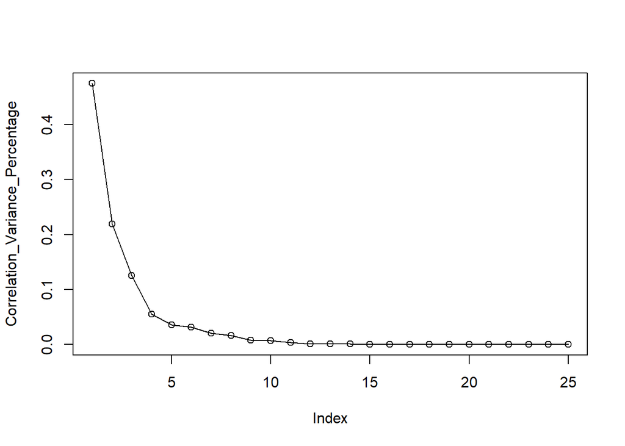

```r
plot(Correlation_Variance_Percentage,type="o")
```

# Need to check for cumulative variance percentage

```r
Correlation_of_cumulative_Variance_Percentage = cumsum(Correlation_Variance_Percentage)
```

Plot cumulative percentage variance

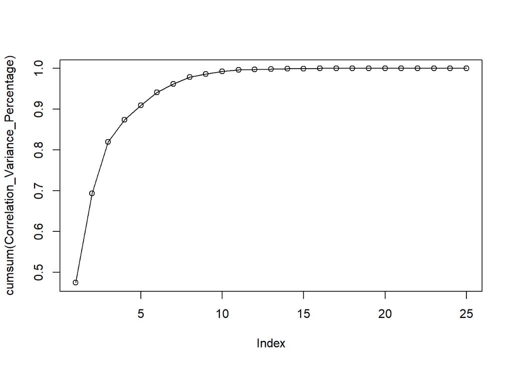

```r
plot(cumsum(Correlation_Variance_Percentage),type="o")
```

### Task 6: Compute the principal component vectors based on your selection in task 5. Comment on your interpretation of the PCs

```r
Correlation_eigenvectors2 = eigen(Correlation)$vectors[,1:9]
colnames(Correlation_eigenvectors2) = c("E1","E2","E3","E4","E5","E6","E7","E8","E9")
row.names(Correlation_eigenvectors2) = colnames(indata_covariance)
round(Correlation_eigenvectors2,digits = 5)
```

```
##                            E1       E2       E3       E4       E5       E6
## PID                  -0.03035  0.18869 -0.16904  0.45861 -0.03343  0.64162
## area                 -0.14874  0.07743  0.13909 -0.12379 -0.78576 -0.21809
## poptotal             -0.28205 -0.04471 -0.11001 -0.02442 -0.03623  0.06352
## popdensity           -0.27884  0.01552 -0.09569  0.04094  0.09356  0.03716
## popwhite             -0.28382 -0.02745 -0.10243 -0.00868 -0.01219  0.05530
## popblack             -0.27455 -0.07903 -0.12279 -0.05631 -0.08670  0.07881
## popamerindian        -0.27993 -0.05809 -0.11251 -0.03976 -0.06055  0.06972
## popasian             -0.28344 -0.03204 -0.10397 -0.00775 -0.00599  0.06032
## popother             -0.27517 -0.07536 -0.12609 -0.05379 -0.07735  0.07776
## percwhite             0.21895  0.19600 -0.20192 -0.07690 -0.21395  0.09989
## percblack            -0.17294 -0.26942  0.20995  0.07921  0.20515 -0.06699
## percamerindan        -0.06988 -0.07019  0.21106 -0.61864  0.07328  0.15876
## percasian            -0.19806  0.19193  0.24826  0.18659  0.12190 -0.07484
## percother            -0.26317  0.01762 -0.07517 -0.08610  0.13746 -0.19964
## popadults            -0.28174 -0.04560 -0.11246 -0.02507 -0.03563  0.06315
## perchsd              -0.07226  0.35970  0.18206  0.06035 -0.17073 -0.04615
## percollege           -0.14667  0.27338  0.29144  0.14781  0.01586  0.04752
## percprof             -0.13666  0.21221  0.38762  0.11576 -0.02344  0.03447
## poppovertyknown      -0.28188 -0.04507 -0.11155 -0.02439 -0.03522  0.06321
## percpovertyknown     -0.00243 -0.05126 -0.37045  0.38645 -0.05845 -0.49946
## percbelowpoverty      0.00266 -0.36159  0.25522  0.19785 -0.11673  0.05090
## percchildbelowpovert -0.02292 -0.38211  0.10407  0.22398 -0.12187 -0.16428
## percadultpoverty     -0.00262 -0.27636  0.36266  0.21229 -0.16189  0.15110
## percelderlypoverty    0.06589 -0.37378  0.02047 -0.01209  0.06428  0.16344
## inmetro              -0.17017  0.19306  0.17506  0.05638  0.36382 -0.29027
##                            E7       E8       E9
## PID                  -0.14143 -0.39756 -0.17422
## area                  0.07135 -0.05794 -0.22464
## poptotal              0.02532  0.04485  0.00165
## popdensity           -0.10452  0.18216  0.04663
## popwhite             -0.00537  0.08012  0.00861
## popblack              0.08802 -0.02835 -0.01290
## popamerindian         0.05088  0.01266 -0.00788
## popasian             -0.00720  0.08397  0.00117
## popother              0.08219 -0.02190 -0.00655
## percwhite             0.12962  0.07868 -0.17653
## percblack            -0.15679 -0.10242  0.20931
## percamerindan        -0.55627 -0.32702 -0.28473
## percasian            -0.19341  0.31629 -0.18263
## percother             0.20210 -0.22532  0.17170
## popadults             0.02421  0.04509  0.00342
## perchsd              -0.20906 -0.02551  0.50424
## percollege           -0.15762  0.15522  0.00878
## percprof             -0.01436  0.17043 -0.13827
## poppovertyknown       0.02418  0.04527  0.00279
## percpovertyknown     -0.47894 -0.05546 -0.30554
## percbelowpoverty      0.06168 -0.05919 -0.04674
## percchildbelowpovert -0.14471 -0.23700  0.20571
## percadultpoverty      0.20454 -0.12796 -0.09817
## percelderlypoverty   -0.03831  0.52625 -0.27404
## inmetro               0.38696 -0.31640 -0.44914
```

Output: We can view the data for all variables’ key components from the output. To make the value more compact and clear, the digits have been rounded to 5.

# Need to check for principal componets

```r
Scaled_Version2 = scale(indata_covariance)
Correlation_E1<-as.matrix(Scaled_Version2) %*% Correlation_eigenvectors2 [,1]
Correlation_E2<-as.matrix(Scaled_Version2) %*% Correlation_eigenvectors2 [,2]
Correlation_E1<-as.matrix(Scaled_Version2) %*% Correlation_eigenvectors2 [,3]
Correlation_E1<-as.matrix(Scaled_Version2) %*% Correlation_eigenvectors2 [,4]
Correlation_E1<-as.matrix(Scaled_Version2) %*% Correlation_eigenvectors2 [,5]
Correlation_E1<-as.matrix(Scaled_Version2) %*% Correlation_eigenvectors2 [,6]
Correlation_E1<-as.matrix(Scaled_Version2) %*% Correlation_eigenvectors2 [,7]
Correlation_E1<-as.matrix(Scaled_Version2) %*% Correlation_eigenvectors2 [,8]
Correlation_E1<-as.matrix(Scaled_Version2) %*% Correlation_eigenvectors2 [,9]
Correlation_Principal_Components <- data.frame(E1,E2)
head(Correlation_Principal_Components)
```

```
##                    E1         E2
## PID        -1.0119993  0.1479073
## area       -1.0120053  0.1479071
## poptotal    5.9253910 -0.8667564
## popdensity -0.8892765  0.1329225
## popwhite    3.3630886 -0.4658343
## popblack    0.7598161 -0.1330184
```

Summary : By combining these two techniques, we were able to generate matrices with fewer elements. Both of these methods are dependable. In the case of cavariance, however, fewer principal components yielded a more accurate result. whereas correlation requires additional principal components.